# Experiential Learning & Gender Stereotypes in Science Education

**2026 China India Insights Conference**  
Carey Business School, Johns Hopkins University

**Muzeeb Shaik**

Kelley School of Business | Indiana University, Bloomington

**With:** John Costello, Huanhuan Shi, Adithya Pattabhiramaiah, Hari Sridhar

## Women remain underrepresented in STEM

### Global Picture

- Women: only **35%** of STEM graduates worldwide
- In the US: **38.8%** of science bachelor’s degrees
- Only **26%** of the US STEM workforce

### India: Our Study Context

- Women: **43%** of total undergraduate enrollment
- But only **29%** in STEM disciplines
- Fewer than **18%** of scientists and engineers in the labor force

**Today’s Talk**

What if **redesigning the science learning experience** could reduce gender stereotypes as a **collateral benefit**, without ever making gender the stated focus?

## Three categories of prior interventions

### 1. Push Campaigns

- Awareness campaigns
- Mass communication
- Public service announcements
- Media messaging

**Goal:** persuade individuals to reconsider stereotypes

Paluck et al. 2021; Hermann et al. 2022

### 2. Girls-Only Programs

- After-school STEM activities
- Mentoring programs
- Interactions with STEM professionals
- Separation as confidence-building

**Goal:** close information gaps, build exposure

Dubetz & Wilson 2013; Levine et al. 2015

### 3. Gender-Congruent Environments

- Female role models
- Feminine classroom décor
- Identity-affirming cues

**Goal:** counteract the masculine coding of science

Master et al. 2016; Breda et al. 2023

**The common limitation**

All three **explicitly position gender as the focal problem** and address it through direct persuasion or identity-targeted messaging, which can trigger **reactance**. Crucially, **none engage boys**, the group that holds the stronger stereotypes and whose perceptions shape whether girls feel they belong in science.

## Our approach: indirect change through equal-status contact

### Mechanism

We change **what students observe**, not what they are told.

- Hands-on science in **mixed-gender, equal-status teams**
- Girls and boys do the same tasks, side by side
- Stereotypes are challenged by **firsthand evidence**, not assertion

### Theoretical anchor

**Intergroup contact theory** (Allport): prejudice declines under four conditions of optimal contact:

- Equal group status within the situation
- Common goals
- Intergroup cooperation
- Authority support

The **MSL program** provides all four as a **byproduct of experiential-learning pedagogy**.

## Setting: Mobile Science Labs in Bodoland, Assam

### The intervention

- **Mobile Science Labs (MSL)** visit rural public schools
- **Ten 2-hour** hands-on sessions over one academic year (about 20 added hours of science)
- Curriculum built on **Kolb’s experiential learning cycle**
- Students work in **mixed-gender teams** on equipment they otherwise never access

[figure not shown]

Mobile Science Lab Vehicle

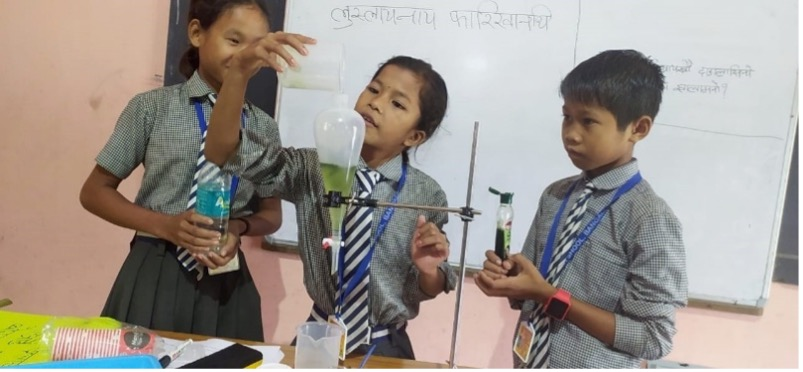

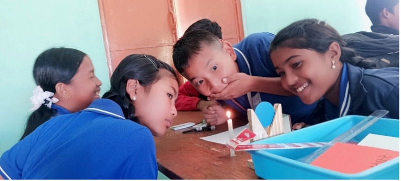

## Research Design

### Sample (Grade 6)

- **N = 2,779 students**, **156 public schools** in Bodoland
- Treatment: **2,171** students, **108** schools received MSL
- Control: **608** students, **48** matched schools, regular instruction
- **Two-wave panel**: baseline and endline within the year
- **Two outcomes:**
  - Gender-stereotype attitude (“Science is for boys more than girls,” 1-5)
  - Science knowledge (% of grade-aligned items correct, 0-100)

### Estimation

Difference-in-differences with student and period fixed effects:

$Y_{it} = \beta\,(Trt_s \times Post_t) + \alpha_i + \tau_t + \varepsilon_{it}$

- $\beta$ (Treatment $\times$ Post) is the **causal effect**
- **Student** fixed effects $\alpha_i$: within-student change
- **Period** fixed effects $\tau_t$; **SEs clustered at the school level**

## Model-Free Evidence

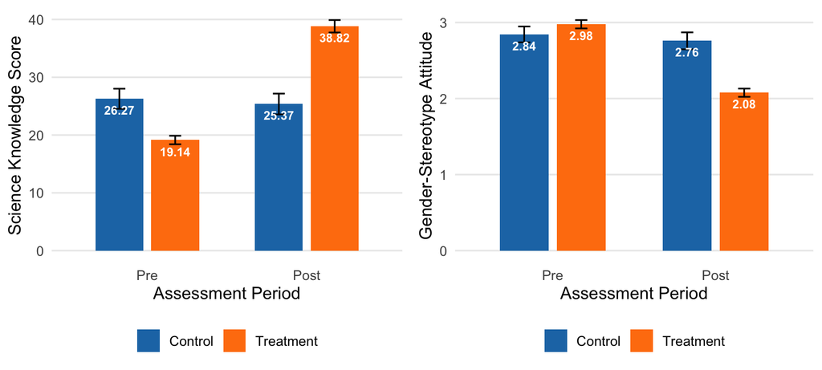

## Main Results: Difference-in-Differences

Panel A: Gender-Stereotype Attitude (1-5)

|  | No FE | School FE | Student + Period FE |
| --- | --- | --- | --- |
| **Treatment × Post** | -0.816*** | -0.785*** | **-0.786***** |
|  | (0.200) | (0.202) | (0.203) |
| N (student-waves) | 5,407 | 5,407 | 5,258 |
| R² | .093 | .275 | .568 |

Panel B: Science Knowledge Score (0-100)

|  | No FE | School FE | Student + Period FE |
| --- | --- | --- | --- |
| **Treatment × Post** | 20.58*** | 20.58*** | **20.58***** |
|  | (3.13) | (3.13) | (3.13) |
| N (student-waves) | 5,558 | 5,558 | 5,558 |
| R² | .138 | .385 | .653 |

*SEs clustered at the school level; *p<.05, **p<.01, ***p<.001. Column (3) is the primary specification.*

**Stereotypes**

**-0.79 points**

≈ **0.61 SD**, roughly a **quarter** of the control baseline (2.84); stable across all specifications

**Knowledge**

**+20.6 points**

large and significant; treated students overtake control by endline

## Heterogeneity in the Effects

### Moderation by student gender

|  | Gender-Stereotype | Science Knowledge |
| --- | --- | --- |
| **Treatment × Post × Male** | **-0.556*** | -0.725 |
|  | (0.218), p = .012 | (3.442), p = .833 |
| Treatment × Post | -0.550* | 20.952*** |
| Post × Male | 0.540** | -1.275 |
| Num. Obs. | 5,258 | 5,558 |

*Student + period FE; SEs clustered at school; *p<.05, **p<.01, ***p<.001; n.s. otherwise. (Paper Table 3.)*

## Robustness of the Stereotype Effect

The **-0.79** stereotype effect is stable across estimators that address non-random school selection:

| Specification | Estimate | 95% CI |
| --- | --- | --- |
| Student + period FE (primary) | -0.786*** | [-1.18, -0.39] |
| School fixed effects | -0.785*** | [-1.18, -0.39] |
| Inverse-propensity weighting | -0.875*** | [-1.32, -0.43] |
| Entropy balancing | -0.824*** | [-1.27, -0.38] |
| Doubly-robust DiD (AIPW) | -0.827*** | [-1.18, -0.48] |

*All estimates ***p<.001. SEs clustered at the school level.*

*Science knowledge attenuates to ~15-16 points under reweighting but stays large and significant.*

## Effects extend beyond the two primary outcomes

### Broader science attitudes (14 items)

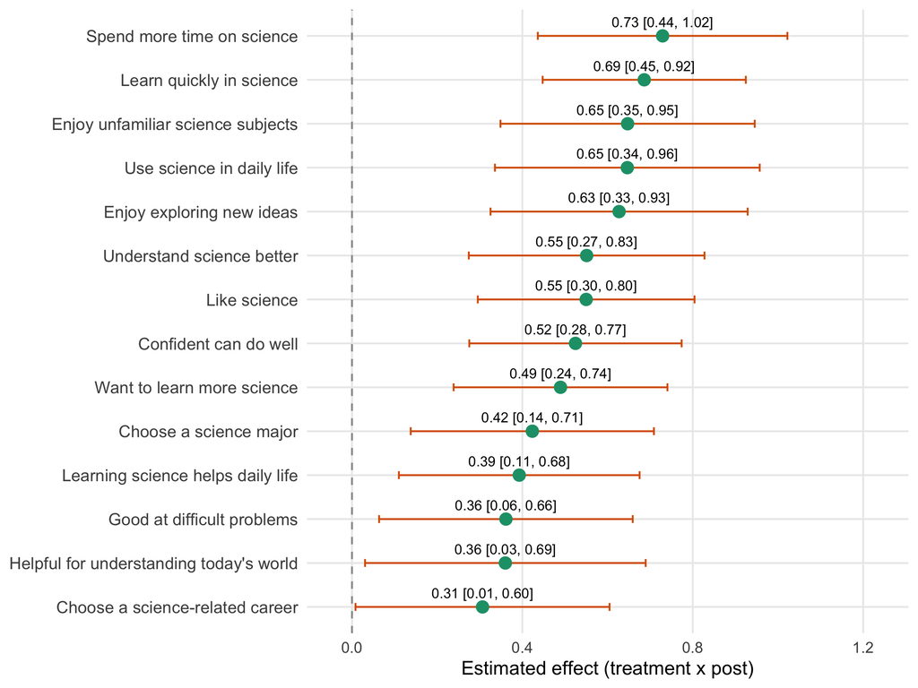

All 14 items move positively and are individually significant (interest, self-efficacy, career intent, value).

### Perceptions of excellence

In a projective vignette, treated students are **less likely to assume a top student is a boy**:

- Science domain: **β = 0.55** (p < .001)
- Language arts: **β = 0.45** (p < .001), a placebo domain

The shift reaches **who belongs**, and extends **beyond science** into language arts.

## But the field study bundles many features

The MSL program combines several things at once:

- Experiential, hands-on pedagogy
- **Mixed-gender** collaborative grouping
- Equal-status peer interaction
- Extended exposure over several sessions
- The field data **cannot isolate** which of these drives the effect, nor the psychological process behind it

**Two pre-registered experiments**

**Study 2 (2×2, N = 1,207):** crosses gender grouping with instructional approach to isolate what does the work.

**Study 3 (N = 605):** measures the psychological mechanisms behind the effect.

## Study 2: Isolating the Mixed-Gender Mechanism

### Design

- **N = 1,207** US adults (CloudResearch), pre-registered
- **2 × 2** between-subjects: gender grouping (single vs. mixed) × instruction (standard vs. experiential)
- Participants imagine being a student in a described school
- Outcome: projective **gender-stereotypical behavioral preference** (1-7; Good 2001)

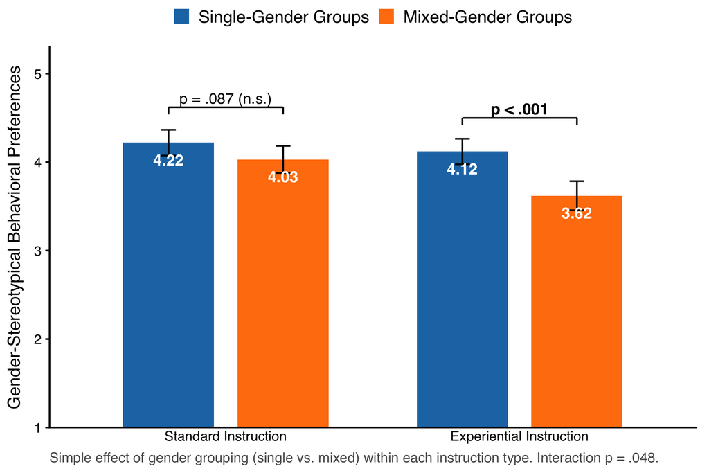

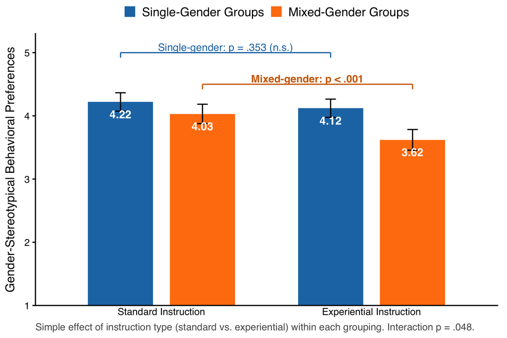

**The interaction (p = .048)**

Mixed-gender grouping cuts stereotypes only under **experiential** learning (3.62 vs. 4.12); equivalently, experiential learning helps only when groups are **mixed**. *(Click to switch the simple-effect view.)*

Study 2 details · Skip Study 3 ⏭

## Study 3: The Psychological Mechanisms

### Design

- **N = 605** US adults, pre-registered
- **Control** (standard, gender-segregated) vs. **mixed-gender experiential learning**
- Replicates the field effect: stereotypical beliefs **4.13 → 3.37** (p < .001)
- Four contact-theory mechanisms measured:
  - **Affective:** empathy, (reduced) anxiety
  - **Cognitive:** trust, knowledge

**Note**

All four mechanisms move in the predicted direction and each mediates when tested **on its own**.

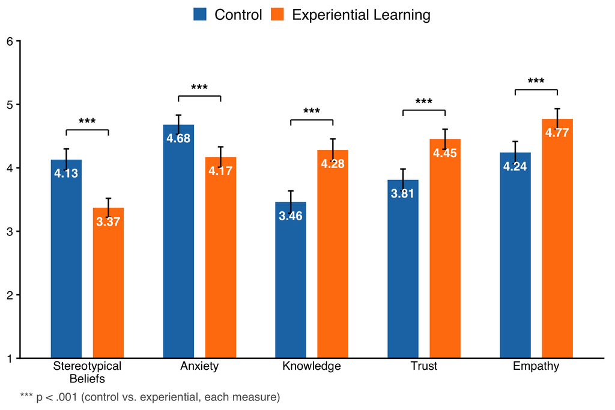

**Condition means**

Experiential learning **lowers stereotypical beliefs** and moves all four mechanisms as predicted (all p < .001).

Study 3 details · Skip to Conclusion ⏭

## Study 3: What Carries the Effect (Parallel Mediation)

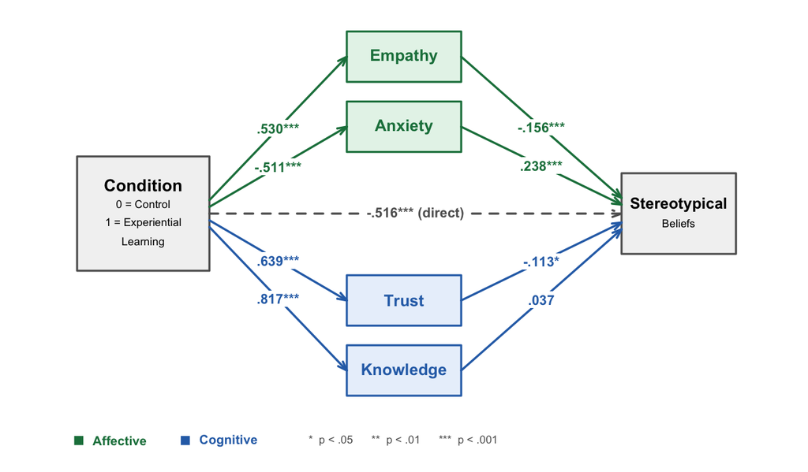

### The affective pathways carry the effect

With all four mechanisms entered **together**, only the affective routes survive:

- **Empathy**: indirect = **-.083** [-.159, -.026]
- **Reduced anxiety**: indirect = **-.122** [-.202, -.054]
- Cognitive **trust** and **knowledge** attenuate to non-significance

**Note**

Consistent with Pettigrew & Tropp (2008): affect, more than cognition, drives contact effects.

## Contribution & Takeaway

So far, we have shown that **experiential learning reduces gender stereotypes** even when the program’s intent had nothing to do with gender, while also **improving students’ science knowledge**, and we show this across:

- Field evidence at scale (**2,779 students, 156 schools**), triangulated by **two pre-registered experiments**

### What we add

- **Service design shapes more than the service delivers:** *how* students participate (experiential) and *with whom* (mixed-gender) reshape beliefs about who belongs, with **no gender messaging**
- Shared experiences let people **learn not just with others, but about others**

## Thank You

Questions & Comments?

Muzeeb Shaik

Assistant Professor

Kelley School of Business

Indiana University - Bloomington

shaikmu@iu.edu

# Appendix

## Study 1: Robustness of the Science Knowledge Effect

**Addressing baseline differences in science knowledge between treatment and control.**

The raw **+20.6** point gain attenuates under matching and reweighting on baseline proficiency, but stays large and significant.

| Specification | Estimate | 95% CI | p |
| --- | --- | --- | --- |
| Student + period FE (primary) | 20.58 | [14.46, 26.71] | < .001 |
| School fixed effects | 20.58 | [14.46, 26.71] | < .001 |
| Inverse-propensity weighting | 14.53 | [7.95, 21.10] | < .001 |
| Entropy balancing | 15.83 | [9.27, 22.39] | < .001 |
| Doubly-robust DiD (AIPW) | 15.52 | [7.47, 23.58] | < .001 |

✓ The knowledge effect holds after controlling for baseline proficiency; the stereotype effect was never confounded by a pre-period gap.

## Study 1: Primary Outcome Measures

### Gender-stereotype attitude

Single-item, baseline and endline:

> **“I feel science is for boys more than girls.”**
- 5-point Likert (1 = Strongly Disagree, 5 = Strongly Agree)
- Higher scores = stronger endorsement
- A concrete, single-referent belief, for which single-item measurement is appropriate (Bergkvist & Rossiter 2007)

### Science knowledge score

- Standardized, grade-appropriate test
- Chemistry, physics, biology aligned with the state curriculum
- Scored as percentage correct (0-100)
- Administered at baseline and endline

## Study 1: Gendered Perception of Excellence (Vignette)

High-performing science student

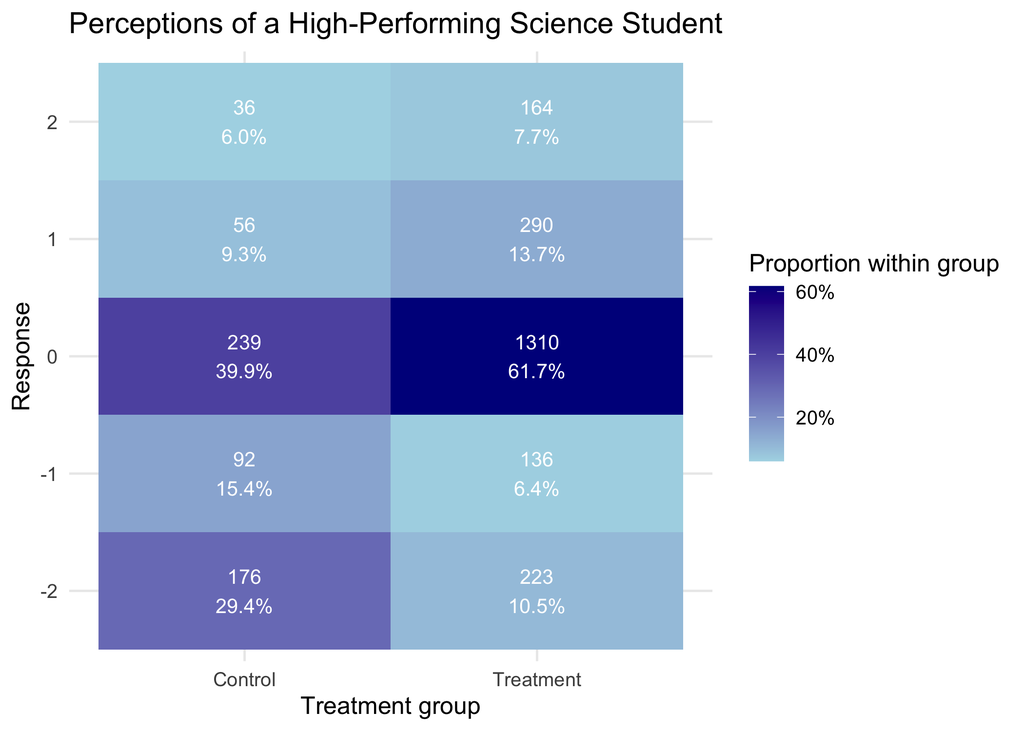

High-performing language-arts student

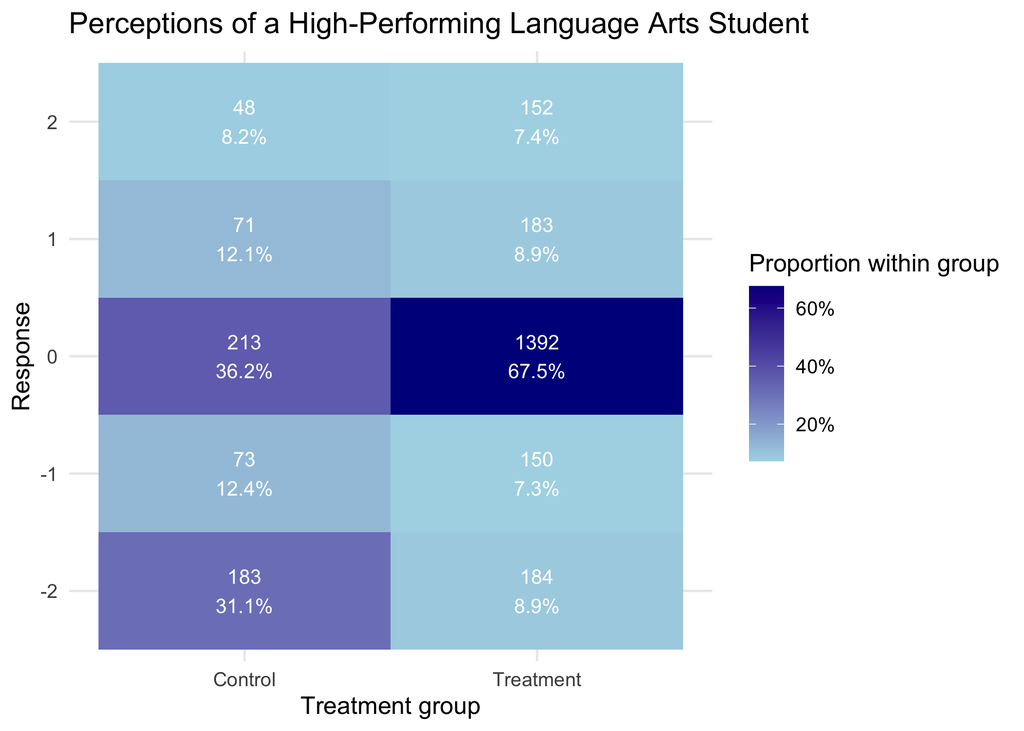

Treated students are more likely to attribute excellence to a girl in **both** domains (science β = 0.55, language arts β = 0.45; difference n.s.), so the intervention shifts broader beliefs about gender and competence, not perceptions of science alone.

## Study 1: Marginal Effects by Gender

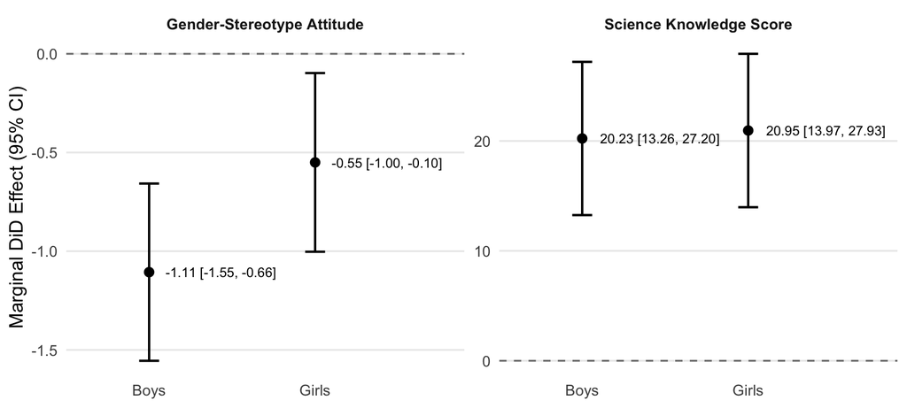

Knowledge gains are statistically equal for boys and girls; the stereotype reduction is about twice as large for boys, though both are significant.

## Study 2: How It Was Run and the Measure

### Procedure

- **N = 1,207** US adults on CloudResearch Connect (M<sub>age</sub> = 44, 62% female); pre-registered
- Participants **imagine being a student** in a described public school (“put yourself in a student’s shoes”)
- **Gender-grouping (seating) manipulation:** single-gender = “boys and girls sit on separate sides of the classroom”; mixed-gender = “boys and girls sit together”
- **Instruction manipulation:** standard = lectures and individual assignments; experiential = a program where groups “operate scientific equipment, observe phenomena, discuss results, and draw conclusions”
- Suspicion probe at the end; no participant identified the hypothesized interaction

### The measure (dependent variable)

Single-item **gender-stereotypical behavioral preference** (Good 2001), adapted to a projective framing (Luchs et al. 2010):

> *“Suppose there is a team competition in this school to see which team is smarter in math and sciences. To what extent do you think the average student in this school would prefer to have men on their team, not women?”*
- **1** = “not at all” to **7** = “very much so”; higher = stronger stereotype
- Asking about **“the average student”** (projective) reduces socially desirable responding

◂ Back to Study 2

## Study 2: Design and Results (detail)

### 2 × 2 design

- **Gender grouping:** single-gender vs. mixed-gender seating and project groups
- **Instruction:** standard (lecture) vs. experiential (hands-on collaboration)
- Same described school; conditions differ only in these two features
- Projective DV reduces socially desirable responding (Luchs et al. 2010)

### Key statistics

- **Main effect, grouping:** mixed 3.83 vs. single 4.17 (p < .001)
- **Main effect, instruction:** experiential 3.87 vs. standard 4.13 (p = .001)
- **Interaction:** F(1, 1203) = 3.91, **p = .048**
- **Simple effect (experiential):** mixed 3.62 vs. single 4.12 (p < .001); a .50-point gap, ~2.5× the .19-point gap under standard instruction

## Study 3: How It Was Run and the Measures

### Procedure and stereotype measure

- **N = 605** US adults (CloudResearch; M<sub>age</sub> = 43, 55% female); pre-registered; two conditions
- **Imagine being a student**; both conditions told the school normally has “gender-segregated rows with limited cross-gender interaction”
- **Experiential condition:** the school launched a program where “students of all genders work together to conduct experiments, observe phenomena, and discuss results” in small mixed-gender groups
- **Stereotype DV** (3 items, α = .876; Lane, Goh & Driver-Linn 2012), projective:
  - “Men are just better at science than women”
  - “I would go to a man instead of a woman for help with a math or science problem”
  - “Genders differ in their skill at science” (women ↔︎ men much better)

### The four contact mechanisms

*(projective, 1–7, presented in randomized order)*

- **Empathy** — affective; 3 items, α = .882 (Swart et al. 2011): *“If a student of the opposite gender were upset, I would also feel upset”*
- **Anxiety** — affective; 6 items, α = .928 (Wölfer et al. 2019): an imagined cross-gender interaction felt anxious / nervous / awkward / (reverse) accepted, comfortable, at ease
- **Trust** — cognitive; 4 items, α = .940 (Turner et al. 2007): *“Students of the opposite gender are trustworthy”*
- **Knowledge** — cognitive; 4 items, α = .884 (Zagefka et al. 2017): know about the opposite gender’s interests, abilities, and values

◂ Back to Study 3

## Study 3: Mechanisms and Mediation (detail)

### Condition means (control → experiential)

- **Stereotypical beliefs:** 4.13 → 3.37 (p < .001)
- **Trust:** 3.81 → 4.45 (p < .001)
- **Knowledge:** 3.46 → 4.28 (p < .001)
- **Empathy:** 4.24 → 4.77 (p < .001)
- **Anxiety:** 4.68 → 4.17 (reduced, p < .001)

### Mediation (PROCESS Model 4)

**Simple mediation (each significant):**

- Trust -.195, Knowledge -.182, Empathy -.147, Anxiety -.171

**Parallel mediation (all four together):**

- **Empathy -.083** [-.159, -.026] ✓
- **Anxiety -.122** [-.202, -.054] ✓
- Trust -.072 (n.s.), Knowledge +.030 (n.s.)

*Affective pathways carry the effect.*